# optimize_final_ziliotto

### Mount to Google Drive:

```python
from google.colab import drive
drive.mount('/content/drive')
```

### Import Libaries:

```python
import pandas as pd
import numpy as np
import matplotlib.pyplot as plt
import seaborn as sns

!pip install pyomo
!apt-get install -y -qq glpk-utils
import pyomo.environ as pe
```

### Reading in Data:

It should be noted that before importing, I converted all data provided into excel sheets that I could view and I normalized team names to match those in the NFL2024SeasonStats so that all names were normalized and wouldn't create issues later.

#### NFLWeek17Stats:

- This df is merged with DKSalaries.xlsx for problem #1

```python
# NFLWeek17 is from 2025
wk17_stats = pd.read_excel('/content/drive/My Drive/Colab Notebooks/optimize/NFLWeek17Stats.xlsx')
wk17_stats.columns = wk17_stats.columns.str.lower() # Lowercasing all titles beforehand to make it easier merging
```

#### DKSalaries:

- This df is merged later with NFLWeek17.xlsx for problem #1
- It is also merged with each sheet of NFL2024SeasonStats.xlsx for problem #2

```python
# DKSalaries is used for problem #1 & problem #2
dk_salaries = pd.read_excel('/content/drive/My Drive/Colab Notebooks/optimize/DKSalaries.xlsx')
dk_salaries.columns = dk_salaries.columns.str.lower() # Lowercasing all titles beforehand to make it easier for merging
```

#### NFL2024SeasonStats:

- These df sheets are merged with DKSalaries.xlsx for problem #2

```python
# PassStats Sheet
pass_stats = pd.read_excel('/content/drive/My Drive/Colab Notebooks/optimize/NFL2024SeasonStats.xlsx', sheet_name = 'PassStats')
pass_stats.columns = pass_stats.columns.str.lower() # Lowercasing all titles beforehand to make it easier merging

# RushStats Sheet
rush_stats = pd.read_excel('/content/drive/My Drive/Colab Notebooks/optimize/NFL2024SeasonStats.xlsx', sheet_name = 'RushStats')
rush_stats.columns = rush_stats.columns.str.lower() # Lowercasing all titles beforehand to make it easier merging

# RcvStats Sheet
rcv_stats = pd.read_excel('/content/drive/My Drive/Colab Notebooks/optimize/NFL2024SeasonStats.xlsx', sheet_name = 'RcvStats')
rcv_stats.columns = rcv_stats.columns.str.lower() # Lowercasing all titles beforehand to make it easier merging

# DefStats Sheet
def_stats = pd.read_excel('/content/drive/My Drive/Colab Notebooks/optimize/NFL2024SeasonStats.xlsx', sheet_name = 'DefStats')
def_stats.columns = def_stats.columns.str.lower() # Lowercasing all titles beforehand to make it easier merging
```

### Creating Dataframes:

#### **For Problem #1**: Merging `wk17_stats` with `dk_salaries`:

For this part, data files are merged using inner joins to ensure that only players in both files' information are merged together.

Merge Offense:

```python
merged_off = (
    pd.merge(
        dk_salaries[['name', 'salary', 'roster position', 'position', 'game info']],
        wk17_stats,
        left_on="name",
        right_on="player",
        how="inner" #only merge data existing in both files
    )
    .query("position != 'DST'")
)
```

Merge Defense:

```python
filtered_dk_salaries = dk_salaries[dk_salaries["position"] == "DST"]
merged_def = pd.merge(
    filtered_dk_salaries[['name', 'salary', 'roster position', 'position', 'game info']],
    wk17_stats,
    left_on="name",
    right_on="player",
    how="inner" #only merge data existing in both files
)
```

#### **For Problem #2**: Merging `pass_stats`,`rush_stats`, `rcv_stats`, and `def_stats` with `dk_salaries`:

Once again, the first merge of files uses inner joins to ensure that only the players present in both files' information are carried into the merged version.

Merge Passing Stats:

```python
merged_pass = (
    pd.merge(
        dk_salaries[['name', 'salary', 'roster position', 'position', 'game info', 'team abbrev', 'avg points per game']],
        pass_stats,
        left_on=["name", "team abbrev", "position"],
        right_on=["player", "team", "position"],
        how="inner" # Only merge data existing in both files
    ).drop_duplicates(subset=['name'])
)
#merged_pass.columns
```

Merge Rush Stats:

```python
merged_rush = (
    pd.merge(
        dk_salaries[['name', 'salary', 'roster position', 'position', 'game info', 'team abbrev', 'avg points per game']],
        rush_stats,
        left_on=["name", "team abbrev", "position"],
        right_on=["player", "team", "position"],
        how="inner" # Only merge data existing in both files
     ).drop_duplicates(subset=['name'])
 )
#merged_rush.columns
```

Merge Rcv Stats:

```python
merged_rcv = (
    pd.merge(
        dk_salaries[['name', 'salary', 'roster position', 'position', 'game info', 'team abbrev', 'avg points per game']],
        rcv_stats,
        left_on=["name", "team abbrev", "position"],
        right_on=["player", "team", "position"],
        how="inner" # Only merge data existing in both files
    ).drop_duplicates(subset=['name'])
)
#merged_rcv.columns
```

Merge Def Stats:

```python
merged_def2 = (
    pd.merge(
        dk_salaries[['name', 'salary', 'roster position', 'position', 'game info', 'team abbrev', 'avg points per game']],
        def_stats,
        left_on=["name"],
        right_on=["player"],
        how="inner" # Only merge data existing in both files
    ).drop_duplicates(subset=['name'])
)
#merged_def2.columns
```

Outer Join `merged_pass` with `merged_rush`:

The outer joins are used to make sure that there aren't duplicated columns being added. `common_cols` is used to identify commonalities between the columns. Then the two files are merged, only including the non-shared columns. `.drop_duplicates(subset=['name'])` removes any duplicate rows based on `'name'`

```python
# Identify common columns for merging
common_cols = list(set(merged_pass.columns) & set(merged_rush.columns))

# Merge merged_pass with merged_rush, including only non-duplicate columns from merged_rush
merged_pass_rush = pd.merge(
    merged_pass,
    merged_rush[[col for col in merged_rush.columns if col not in merged_pass.columns] + common_cols],
    on=common_cols,
    how='outer'
).drop_duplicates(subset=['name'])
#merged_pass_rush.columns
```

Outer Join `merged_pass_rush` with `merged_rcv`:

The outer joins are used to make sure that there aren't duplicated columns being added. `common_cols` is used to identify commonalities between the columns. Then the two files are merged, only including the non-shared columns. `.drop_duplicates(subset=['name'])` removes any duplicate rows based on `'name'`

```python
# Identify common columns for merging
common_cols2 = list(set(merged_pass_rush.columns) & set(merged_rcv.columns) - {'rank'})

# Merge merged_pass with merged_rush, including only non-duplicate columns from merged_rush
merged_off2 = pd.merge(
    merged_pass_rush,
    merged_rcv[[col for col in merged_rcv.columns if col not in merged_pass_rush.columns] + common_cols2],
    on=common_cols2,
    how='outer'
).drop_duplicates(subset=['name'])
#merged_off2.columns
```

Outer Join `merged_off2` with `merged_def2`:

The outer joins are used to make sure that there aren't duplicated columns being added. `common_cols` is used to identify commonalities between the columns. Then the two files are merged, only including the non-shared columns. `.drop_duplicates(subset=['name'])` removes any duplicate rows based on `'name'`

```python
# Identify common columns for merging
common_cols3 = list(set(merged_off2.columns) & set(merged_def2.columns))

# Merge merged_pass with merged_rush, including only non-duplicate columns from merged_rush
combined_df2 = pd.merge(
    merged_off2,
    merged_def2[[col for col in merged_def2.columns if col not in merged_off2.columns] + common_cols3],
    on=common_cols3,
    how='outer'
).drop_duplicates(subset=['name'])
# combined_df2.columns
```

### Data Reconfiguration and Editing:

Extract `home team` Into New Column:

```python
# Extract the first part of 'game_info' before the space and rename it 'home team'
combined_df2["home team"] = combined_df2["game info"].str.split("@").str[0]
```

Extract `away team` Into New Column:

```python
# Extract the team after the '@' in 'game_info' and rename it 'away team'
combined_df2['away team'] = combined_df2['game info'].str.split('@').str[1].str[:3]
```

Extract `opponent team` Into New Column:

```python
# Identify the opponent team based on the player's actual team
combined_df2['opponent team'] = combined_df2.apply(
    lambda row: row['away team'] if row['team abbrev'] == row['home team'] else row['home team'], axis=1
)
combined_df2
```

|  | name | salary | roster position | position | game info | team abbrev | avg points per game | player | age | team | ... | 1d | pen | pen yds | pen 1d | score drv pct | to drv pct | exp pts contributed | home team | away team | opponent team |
| --- | --- | --- | --- | --- | --- | --- | --- | --- | --- | --- | --- | --- | --- | --- | --- | --- | --- | --- | --- | --- | --- |
| 0 | A.J. Brown | 7800 | WR/FLEX | WR | DAL@PHI 12/29/2024 01:00PM ET | PHI | 18.28 | A.J. Brown | 27 | PHI | ... | NaN | NaN | NaN | NaN | NaN | NaN | NaN | DAL | PHI | DAL |
| 1 | AJ Barner | 3200 | TE/FLEX | TE | SEA@CHI 12/26/2024 08:15PM ET | SEA | 4.27 | AJ Barner | 22 | SEA | ... | NaN | NaN | NaN | NaN | NaN | NaN | NaN | SEA | CHI | CHI |
| 2 | Aaron Rodgers | 5700 | QB | QB | NYJ@BUF 12/29/2024 01:00PM ET | NYJ | 16.28 | Aaron Rodgers | 41 | NYJ | ... | NaN | NaN | NaN | NaN | NaN | NaN | NaN | NYJ | BUF | BUF |
| 3 | Adam Thielen | 5700 | WR/FLEX | WR | CAR@TB 12/29/2024 01:00PM ET | CAR | 13.14 | Adam Thielen | 34 | CAR | ... | NaN | NaN | NaN | NaN | NaN | NaN | NaN | CAR | TB | TB |
| 4 | Adam Trautman | 2800 | TE/FLEX | TE | DEN@CIN 12/28/2024 04:30PM ET | DEN | 2.82 | Adam Trautman | 27 | DEN | ... | NaN | NaN | NaN | NaN | NaN | NaN | NaN | DEN | CIN | CIN |
| ... | ... | ... | ... | ... | ... | ... | ... | ... | ... | ... | ... | ... | ... | ... | ... | ... | ... | ... | ... | ... | ... |
| 360 | Zach Charbonnet | 6000 | RB/FLEX | RB | SEA@CHI 12/26/2024 08:15PM ET | SEA | 11.35 | Zach Charbonnet | 23 | SEA | ... | NaN | NaN | NaN | NaN | NaN | NaN | NaN | SEA | CHI | CHI |
| 361 | Zach Davidson | 2500 | TE/FLEX | TE | NYJ@BUF 12/29/2024 01:00PM ET | BUF | 0.50 | Zach Davidson | 26 | BUF | ... | NaN | NaN | NaN | NaN | NaN | NaN | NaN | NYJ | BUF | NYJ |
| 362 | Zach Ertz | 3800 | TE/FLEX | TE | ATL@WAS 12/29/2024 08:20PM ET | WAS | 9.12 | Zach Ertz | 34 | WAS | ... | NaN | NaN | NaN | NaN | NaN | NaN | NaN | ATL | WAS | ATL |
| 363 | Zack Moss | 4000 | RB/FLEX | RB | DEN@CIN 12/28/2024 04:30PM ET | CIN | 10.36 | Zack Moss | 27 | CIN | ... | NaN | NaN | NaN | NaN | NaN | NaN | NaN | DEN | CIN | DEN |
| 364 | Zay Jones | 3000 | WR/FLEX | WR | ARI@LAR 12/28/2024 08:10PM ET | ARI | 0.54 | Zay Jones | 29 | ARI | ... | NaN | NaN | NaN | NaN | NaN | NaN | NaN | ARI | LAR | LAR |

365 rows × 73 columns

Create New Column `game` Showing Home Team vs. Away Team:

```python
# Replace the '@' with 'vs' in 'game_info'; Remove everything after the space (removes date/time)
merged_def["game"] = merged_def["game info"].str.replace("@", "vs", regex=False).str.split(" ").str[0]
merged_off["game"] = merged_off["game info"].str.replace("@", "vs", regex=False).str.split(" ").str[0]
combined_df2["game"] = combined_df2["game info"].str.replace("@", "vs", regex=False).str.split(" ").str[0]
```

#### Cleaning and Standardizing Game Information

When working with game data, I needed to clean the game info column to make it more uniform and easier to use. Specifically, I replaced '@' with 'vs' and removed any additional information, such as date and time, that appeared after a space. This process was applied to multiple DataFrames.

#### Steps Taken:

Replace '@' with 'vs': Since '@' often signifies an away game, I standardized it by converting it to 'vs', making the notation consistent.

Remove Unnecessary Information: Using `.str.split(" ").str[0`], I extracted only the first part of the `game info` string, eliminating date/time details.

Apply to Multiple DataFrames: These transformations were applied to `merged_def`, `merged_off`, and `combined_df2` to ensure consistency across datasets.

#### Final Implementation:

```
merged_def["game"] = merged_def["game info"].str.replace("@", "vs", regex=False).str.split(" ").str[0]
merged_off["game"] = merged_off["game info"].str.replace("@", "vs", regex=False).str.split(" ").str[0]
combined_df2["game"] = combined_df2["game info"].str.replace("@", "vs", regex=False).str.split(" ").str[0]
```

This approach ensures that the game identifiers are formatted consistently, making them easier to analyze and match across datasets.

### Data Cleaning:

```python
# Function to clean text by replacing umlauts and special characters
def clean_text(text):
    if isinstance(text, str):
        text = text.replace("ä", "a").replace("ö", "o").replace("ü", "u").replace("ß", "ss")
        text = text.replace("Ä", "A").replace("Ö", "O").replace("Ü", "U")
    return text

# Function to clean entire dataframe
def clean_dataframe(df):
    df = df.drop_duplicates()  # Remove duplicate rows
    df = df.fillna(0)  # Replace NaN values with 0
    df = df.map(clean_text)  # Apply cleaning function to all values
    df.columns = [clean_text(col) for col in df.columns]  # Clean column names
    return df

# Call the functions for cleaning the dataframes SEPERATELY
merged_off = clean_dataframe(merged_off)  # Clean merged_off
merged_def = clean_dataframe(merged_def)  # Clean merged_def
combined_df2 = clean_dataframe(combined_df2)  # Clean combined_df2
```

Code Explained:

```
def clean_text(text):
    if isinstance(text, str):
        text = text.replace("ä", "a").replace("ö", "o").replace("ü", "u").replace("ß", "ss")
        text = text.replace("Ä", "A").replace("Ö", "O").replace("Ü", "U")
    return text
```

- Replaces German umlauts and ß with their ASCII equivalents

```
def clean_dataframe(df):
    df = df.drop_duplicates()  # Remove duplicate rows
    df = df.fillna(0)  # Replace NaN values with 0
    df = df.map(clean_text)  # Apply cleaning function to all values
    df.columns = [clean_text(col) for col in df.columns]  # Clean column names
    return df
```

- Deduplicates rows.
- Fills missing values with 0.
- Cleans all text values and column names.

### Total Fantasy Points Calculations (Problem 1):

**Offense** Fantasy Point Calculation (all players except DST):

- This does not include the ttl point allowed in calculations, as it is automatically 0 for all players because they are not a DST. For this reason, it was easiest to exclude from calculations to ensure that it doesn't add an extra 10 points for every player that would need to be subtracted later.
- Additionally, I did not include the defense-specific calculations because they do not impact the total fantasy points for non-defense players and would be extra code useless code.

```python
merged_off["total fantasy points"] = (
    (merged_off["pass td"] * 4) +  # passing tds
    (merged_off["pass yds"] * 0.04) +  # passing yds (1 pt per 25 yards)
    (merged_off["pass yds"].apply(lambda x: 3 if x >= 300 else 0)) +  # 300+ passing extra
    (merged_off["pass int"] * -1) +  # pass int
    (merged_off["rush td"] * 6) +  # rush tds
    (merged_off["rush yds"] * 0.1) +  # rushing yds (1 pt per 10 yards)
    (merged_off["rush yds"].apply(lambda x: 3 if x >= 100 else 0)) +  # 100+ rushing extra
    (merged_off["rcv td"] * 6) +  # receiving tds
    (merged_off["rcv yds"] * 0.1) +  # receiving yds (1 pt per 10 yards)
    (merged_off["rcv yds"].apply(lambda x: 3 if x >= 100 else 0)) +  # 100+ receiving extra
    (merged_off["rec"] * 1) +  # receptions
    (merged_off["punt/kickoff/fg return for td"] * 6) +  # return tds
    (merged_off["fl"] * -1) +  # fumbles lost
    (merged_off["2pt conversions"] * 2) +  # 2-point conversions
    (merged_off["fumble recovery td"] * 6)  # offensive fmb recovery tds
)
```

### Calculating Offensive Total Fantasy Points

When designing a fantasy football scoring system, I needed to calculate total fantasy points based on various player stats. I structured the formula to account for passing, rushing, receiving, and miscellaneous scoring factors.

#### **Steps Taken:**

1. **Passing Stats:**
   - Award 4 points per passing touchdown (`pass td`).
   - Grant 0.04 points per passing yard (equivalent to 1 point per 25 yards).
   - Add a 3-point bonus for 300+ passing yards.
   - Deduct 1 point per interception (`pass int`).
2. **Rushing Stats:**
   - Award 6 points per rushing touchdown (`rush td`).
   - Grant 0.1 points per rushing yard (equivalent to 1 point per 10 yards).
   - Add a 3-point bonus for 100+ rushing yards.
3. **Receiving Stats:**
   - Award 6 points per receiving touchdown (`rcv td`).
   - Grant 0.1 points per receiving yard (equivalent to 1 point per 10 yards).
   - Add a 3-point bonus for 100+ receiving yards.
   - Grant 1 point per reception (`rec`).
4. **Miscellaneous Stats:**
   - Award 6 points per punt, kickoff, or field goal return touchdown.
   - Deduct 1 point per lost fumble (`fl`).
   - Award 2 points per successful two-point conversion (`2pt conversions`).
   - Award 6 points per offensive fumble recovery touchdown.

#### **Final Implementation:**

```
merged_off["total fantasy points"] = (
    (merged_off["pass td"] * 4) +  # passing tds
    (merged_off["pass yds"] * 0.04) +  # passing yds (1 pt per 25 yards)
    (merged_off["pass yds"].apply(lambda x: 3 if x >= 300 else 0)) +  # 300+ passing extra
    (merged_off["pass int"] * -1) +  # pass int
    (merged_off["rush td"] * 6) +  # rush tds
    (merged_off["rush yds"] * 0.1) +  # rushing yds (1 pt per 10 yards)
    (merged_off["rush yds"].apply(lambda x: 3 if x >= 100 else 0)) +  # 100+ rushing extra
    (merged_off["rcv td"] * 6) +  # receiving tds
    (merged_off["rcv yds"] * 0.1) +  # receiving yds (1 pt per 10 yards)
    (merged_off["rcv yds"].apply(lambda x: 3 if x >= 100 else 0)) +  # 100+ receiving extra
    (merged_off["rec"] * 1) +  # receptions
    (merged_off["punt/kickoff/fg return for td"] * 6) +  # return tds
    (merged_off["fl"] * -1) +  # fumbles lost
    (merged_off["2pt conversions"] * 2) +  # 2-point conversions
    (merged_off["fumble recovery td"] * 6)  # offensive fumble recovery tds
)
```

This approach ensures an accurate calculation of fantasy points, applying bonuses and penalties where needed to reflect a player's performance.

**Defense** Fantasy Point Calculation (only DST):

- Because I am calculating defense fantasy points, I did not include the offense calculations for defense fantasy points. It is the same either way, but extra code for no reason.

```python
merged_def["total fantasy points"] = (
    (merged_def["sack"] * 1) + # sacks
    (merged_def["interception"] * 2) +  # int
    (merged_def["fumble recovery"] * 2) +  # fmb recoveries
    (merged_def["interception return td"] * 6) +  # int return td
    (merged_def["fumble recovery td"] * 6) +  # fmb recovery td
    (merged_def["blocked punt or fg return td"] * 6) +  # blocked punt/fg return td
    (merged_def["safety"] * 2) +  # safety
    (merged_def["blocked kicks"] * 2) +  # blocked kicks
    (merged_def["2pt conversions"] * 2) +  # 2 pt conversion (defensive return)

    # points allowed
    (merged_def["ttl pts allowed"].apply(lambda x: 10 if x == 0 else 0)) +  # 0 pts allowed
    (merged_def["ttl pts allowed"].apply(lambda x: 7 if 1 <= x <= 6 else 0)) +  # 1-6 pts allowed
    (merged_def["ttl pts allowed"].apply(lambda x: 4 if 7 <= x <= 13 else 0)) +  # 7-13 pts allowed
    (merged_def["ttl pts allowed"].apply(lambda x: 1 if 14 <= x <= 20 else 0)) +  # 14-20 pts allowed
    (merged_def["ttl pts allowed"].apply(lambda x: -1 if 28 <= x <= 34 else 0)) +  # 28-34 pts allowed
    (merged_def["ttl pts allowed"].apply(lambda x: -4 if x >= 35 else 0))  # 35+ pts allowed
)
```

### Calculating Defensive Fantasy Points

For fantasy football scoring, I needed to compute defensive fantasy points by considering key defensive plays and points allowed. This system rewards defensive performance while penalizing teams for allowing too many points.

#### **Steps Taken:**

1. **Defensive Statistics:**
   - Award 1 point per sack (`sack`).
   - Award 2 points per interception (`interception`).
   - Award 2 points per fumble recovery (`fumble recovery`).
   - Award 6 points for touchdowns scored off interceptions (`interception return td`).
   - Award 6 points for touchdowns scored off fumble recoveries (`fumble recovery td`).
   - Award 6 points for touchdowns from blocked punts or field goals (`blocked punt or fg return td`).
   - Award 2 points per safety (`safety`).
   - Award 2 points per blocked kick (`blocked kicks`).
   - Award 2 points for defensive returns of a two-point conversion (`2pt conversions`).
2. **Points Allowed Adjustments:**
   - Grant 10 points if the defense allows 0 points.
   - Grant 7 points if the defense allows 1-6 points.
   - Grant 4 points if the defense allows 7-13 points.
   - Grant 1 point if the defense allows 14-20 points.
   - Deduct 1 point if the defense allows 28-34 points.
   - Deduct 4 points if the defense allows 35 or more points.

#### **Final Implementation:**

```
merged_def["total fantasy points"] = (
    (merged_def["sack"] * 1) +  # sacks
    (merged_def["interception"] * 2) +  # int
    (merged_def["fumble recovery"] * 2) +  # fmb recoveries
    (merged_def["interception return td"] * 6) +  # int return td
    (merged_def["fumble recovery td"] * 6) +  # fmb recovery td
    (merged_def["blocked punt or fg return td"] * 6) +  # blocked punt/fg return td
    (merged_def["safety"] * 2) +  # safety
    (merged_def["blocked kicks"] * 2) +  # blocked kicks
    (merged_def["2pt conversions"] * 2) +  # 2 pt conversion (defensive return)

    # points allowed
    (merged_def["ttl pts allowed"].apply(lambda x: 10 if x == 0 else 0)) +  # 0 pts allowed
    (merged_def["ttl pts allowed"].apply(lambda x: 7 if 1 <= x <= 6 else 0)) +  # 1-6 pts allowed
    (merged_def["ttl pts allowed"].apply(lambda x: 4 if 7 <= x <= 13 else 0)) +  # 7-13 pts allowed
    (merged_def["ttl pts allowed"].apply(lambda x: 1 if 14 <= x <= 20 else 0)) +  # 14-20 pts allowed
    (merged_def["ttl pts allowed"].apply(lambda x: -1 if 28 <= x <= 34 else 0)) +  # 28-34 pts allowed
    (merged_def["ttl pts allowed"].apply(lambda x: -4 if x >= 35 else 0))  # 35+ pts allowed
)
```

This approach ensures an accurate calculation of fantasy points based on defensive performance while incorporating bonuses and penalties for points allowed.

### Boosted Avg Points Calculation (Problem 2):

#### Identify Weak Defense Teams:

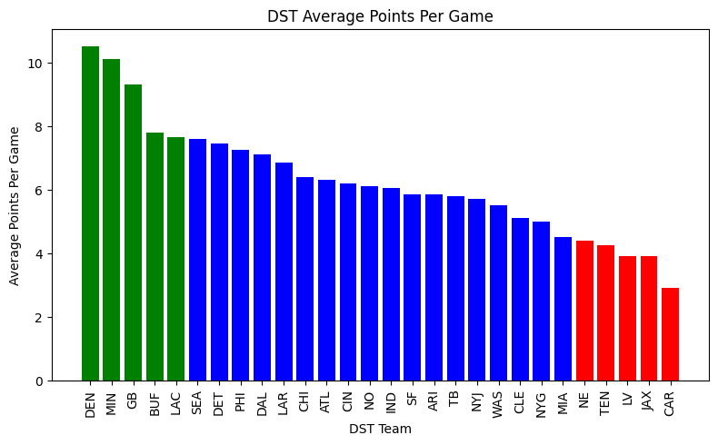

```python
# Filter for DST players
dst_players = combined_df2[combined_df2['position'] == 'DST']

# Sort by average points per game
dst_players = dst_players.sort_values('avg points per game', ascending=False)

# Determine bottom 10 and top 10 teams
bottom_5 = dst_players.tail(5)
top_5 = dst_players.head(5)

# Create the plot
plt.figure(figsize=(8, 5))
plt.bar(dst_players['team abbrev'], dst_players['avg points per game'], color='blue')

# Color the bottom 10 teams red
plt.bar(bottom_5['team abbrev'], bottom_5['avg points per game'], color='red')

# Color the top 10 teams green
plt.bar(top_5['team abbrev'], top_5['avg points per game'], color='green')

plt.xlabel('DST Team')
plt.ylabel('Average Points Per Game')
plt.title('DST Average Points Per Game')
plt.xticks(rotation=90)
plt.tight_layout()
plt.show()
```

#### Boosted Average Points Per Game Calculation

```python
weak_def = ['NE', 'TEN', 'LV', 'JAX', 'CAR' ] # identified weak defense teams

# Calculate boosted avg points per game using lambda functions
combined_df2["boosted avg points per game"] = combined_df2["avg points per game"] * (
    combined_df2["games started"].apply(lambda x: 1.05 if x >= 16 else 1) *
    combined_df2.apply(lambda row: 1.10 if row["home team"] == row["team abbrev"] else 1, axis=1) *
    combined_df2.apply(lambda row: 1.10 if row["position"] == "WR" and row["rcv yds"] >= 1000 else 1, axis=1) *
    combined_df2.apply(lambda row: 1.10 if row["position"] == "TE" and row["rcv yds"] >= 800 else 1, axis=1) *
    combined_df2.apply(lambda row: 1.15 if row["position"] in ["WR", "TE"] and row["rcv td"] >= 10 else 1, axis=1) *
    combined_df2.apply(lambda row: 1.10 if row["position"] == "QB" and row["pass yds"] >= 3750 else 1, axis=1) *
    combined_df2.apply(lambda row: 1.10 if row["position"] == "DST" and row["to"] >= combined_df2.loc[combined_df2["position"] == "DST", "to"].quantile(0.75) else 1, axis=1) *
    combined_df2.apply(lambda row: 1.10 if row["position"] == "DST" and row["opponent team"] == weak_def else 1, axis=1)
)
combined_df2[["avg points per game", "boosted avg points per game"]]
```

|  | avg points per game | boosted avg points per game |
| --- | --- | --- |
| 0 | 18.28 | 20.10800 |
| 1 | 4.27 | 4.69700 |
| 2 | 16.28 | 20.68374 |
| 3 | 13.14 | 14.45400 |
| 4 | 2.82 | 3.10200 |
| ... | ... | ... |
| 360 | 11.35 | 12.48500 |
| 361 | 0.50 | 0.50000 |
| 362 | 9.12 | 9.57600 |
| 363 | 10.36 | 10.36000 |
| 364 | 0.54 | 0.59400 |

365 rows × 2 columns

### Calculating Boosted Average Points per Game

To refine player performance analysis, I created a boosted average points per game metric by applying various multipliers based on player stats and situational factors. This method accounts for game experience, home-field advantage, and statistical achievements.

#### **Steps Taken:**

[output not shown]

This approach enhances traditional fantasy metrics by incorporating player stats and game context, allowing for a more dynamic analysis of performance potential.

### More Data Cleaning:

Fixing Column Names:

```python
# Drop 'player' column from merged dataframes after merge
merged_off = merged_off.drop(columns=['player']) #offense
merged_def = merged_def.drop(columns=['player']) #deffense
combined_df2 = combined_df2.drop(columns=['player']) #combined

# Drop 'team' column from combined_df2 after merge
combined_df2 = combined_df2.drop(columns=['team']) #combined

# Rename 'name' column as 'player' (to ensure consistency across files)
merged_off = merged_off.rename(columns={'name': 'player'}) # offense
merged_def = merged_def.rename(columns={'name': 'player'}) # defense
combined_df2 = combined_df2.rename(columns={'name': 'player'}) # combined
```

### Saving Dfs to Excel

Sending Dfs to Excel File (for my viewing):

```python
# Save the cleaned and merged dataframe to a new excel file (for ease of viewing)
merged_off.to_excel("/content/drive/My Drive/Colab Notebooks/optimize/CleanedMergedOffense.xlsx", index=False) # offense
merged_def.to_excel("/content/drive/My Drive/Colab Notebooks/optimize/CleanedMergedDefense.xlsx", index=False) # defense
combined_df2.to_excel("/content/drive/My Drive/Colab Notebooks/optimize/CleanedMergedCombined2.xlsx", index=False) # combined
```

Viewing cleaned dataframes:

```python
# Display the cleaned merged OFFENSE dataframe
cleaned_off = pd.read_excel("/content/drive/My Drive/Colab Notebooks/optimize/CleanedMergedOffense.xlsx")
# cleaned_off
```

```python
#Display the cleaned merged DEFENSE dataframe
cleaned_def = pd.read_excel("/content/drive/My Drive/Colab Notebooks/optimize/CleanedMergedDefense.xlsx")
# cleaned_def
```

```python
#Display the cleaned merged COMBINED_DF2 dataframe
cleaned_combined_df2 = pd.read_excel("/content/drive/My Drive/Colab Notebooks/optimize/CleanedMergedCombined2.xlsx")
# cleaned_combined_df2
```

### Recombining `merged_off` with `merged_def`:

```python
combined_df = pd.concat([merged_off, merged_def], ignore_index=True)
combined_df
```

|  | player | salary | roster position | position | game info | tm | pass cmp | pass att | pass yds | pass td | ... | blocked kicks | sack | interception | fumble recovery | punt/kickoff/fg return for td | interception return td | fumble recovery td | blocked punt or fg return td | game | total fantasy points |
| --- | --- | --- | --- | --- | --- | --- | --- | --- | --- | --- | --- | --- | --- | --- | --- | --- | --- | --- | --- | --- | --- |
| 0 | Saquon Barkley | 8600 | RB/FLEX | RB | DAL@PHI 12/29/2024 01:00PM ET | PHI | 0 | 0 | 0 | 0 | ... | 0 | 0 | 0 | 0 | 0 | 0 | 0 | 0 | DALvsPHI | 21.90 |
| 1 | Josh Allen | 8500 | QB | QB | NYJ@BUF 12/29/2024 01:00PM ET | BUF | 16 | 27 | 182 | 2 | ... | 0 | 0 | 0 | 0 | 0 | 0 | 0 | 0 | NYJvsBUF | 22.98 |
| 2 | Jahmyr Gibbs | 8500 | RB/FLEX | RB | DET@SF 12/30/2024 08:15PM ET | DET | 0 | 0 | 0 | 0 | ... | 0 | 0 | 0 | 0 | 0 | 0 | 0 | 0 | DETvsSF | 29.30 |
| 3 | Ja'Marr Chase | 8400 | WR/FLEX | WR | DEN@CIN 12/28/2024 04:30PM ET | CIN | 0 | 0 | 0 | 0 | ... | 0 | 0 | 0 | 0 | 0 | 0 | 0 | 0 | DENvsCIN | 22.20 |
| 4 | Justin Jefferson | 8300 | WR/FLEX | WR | GB@MIN 12/29/2024 04:25PM ET | MIN | 0 | 0 | 0 | 0 | ... | 0 | 0 | 0 | 0 | 0 | 0 | 0 | 0 | GBvsMIN | 17.20 |
| ... | ... | ... | ... | ... | ... | ... | ... | ... | ... | ... | ... | ... | ... | ... | ... | ... | ... | ... | ... | ... | ... |
| 280 | New England Patriots | 2400 | DST | DST | LAC@NE 12/28/2024 01:00PM ET | NEW | 0 | 0 | 0 | 0 | ... | 0 | 0 | 0 | 0 | 0 | 0 | 0 | 0 | LACvsNE | -4.00 |
| 281 | San Francisco 49ers | 2300 | DST | DST | DET@SF 12/30/2024 08:15PM ET | SFO | 0 | 0 | 0 | 0 | ... | 0 | 2 | 0 | 1 | 0 | 0 | 0 | 0 | DETvsSF | 0.00 |
| 282 | New York Giants | 2300 | DST | DST | IND@NYG 12/29/2024 01:00PM ET | NYG | 0 | 0 | 0 | 0 | ... | 0 | 2 | 2 | 2 | 1 | 0 | 0 | 0 | INDvsNYG | 9.00 |
| 283 | Carolina Panthers | 2200 | DST | DST | CAR@TB 12/29/2024 01:00PM ET | CAR | 0 | 0 | 0 | 0 | ... | 0 | 2 | 0 | 2 | 0 | 0 | 0 | 0 | CARvsTB | 2.00 |
| 284 | New York Jets | 2100 | DST | DST | NYJ@BUF 12/29/2024 01:00PM ET | NYJ | 0 | 0 | 0 | 0 | ... | 0 | 0 | 0 | 1 | 0 | 0 | 0 | 0 | NYJvsBUF | -2.00 |

285 rows × 38 columns

## **Problem 1**

### Optimal lineup based on how the players performed during their actual games. What selection of NFL players would have created the best possible entry for this DraftKings competition?

**Objective Function**

Maximize `total fantasy points`

**Decision Variables**

QB, RB1, RB2, WR1, WR2, WR3, TE, 1 FLEX (RB/WR/TE), DST

**Constraints**

- Fantasy team == nine “players” (a team defense/special teams counts as one player)
- Total salary of players <= $50,000
- Players >= different games
- 1 Quarterback (QB)
- 2 Running Backs (RB)
- 3 Wide Receivers (WR)
- 1 Tight End (TE)
- 1 FLEXible position (a RB, WR, or TE)
- 1 Team’s Defense/Special Teams (DST)

#### Optimizing Fantasy Points Model:

```python
# indexes
DV_indexes = combined_df.index
flex = combined_df[combined_df['position'].isin(['RB', 'WR', 'TE'])].index

# defining model
model = pe.ConcreteModel()

# binary decision variables
model.y = pe.Var(DV_indexes, domain=pe.Binary)

# objective function (maximize total fantasy points)
model.obj = pe.Objective(
    expr=sum(combined_df.loc[i, 'total fantasy points'] * model.y[i] for i in DV_indexes),
    sense=pe.maximize
)

# constraints
model.tot_players = pe.Constraint(expr=sum(model.y[i] for i in DV_indexes) == 9) # nine total players on team
model.tot_salary = pe.Constraint(expr=sum(combined_df.loc[i, 'salary'] * model.y[i] for i in DV_indexes) <= 50000) # salaries sum to <= $50,000
model.num_qb = pe.Constraint(expr=sum(model.y[i] for i in DV_indexes if combined_df.loc[i, 'position'] == 'QB') == 1) # 1 QB
model.num_rb = pe.Constraint(expr=sum(model.y[i] for i in DV_indexes if combined_df.loc[i, 'position'] == 'RB') >= 2) # 2 RB
model.num_wr = pe.Constraint(expr=sum(model.y[i] for i in DV_indexes if combined_df.loc[i, 'position'] == 'WR') >= 3) # 3 WR
model.num_te = pe.Constraint(expr=sum(model.y[i] for i in DV_indexes if combined_df.loc[i, 'position'] == 'TE') >= 1) # 1 TE
model.num_flex = pe.Constraint(expr=sum(model.y[i] for i in flex) >= 2) # 1 additional RB, WR, or TE
model.num_dst = pe.Constraint(expr=sum(model.y[i] for i in DV_indexes if combined_df.loc[i, 'position'] == 'DST') == 1) # 1 DST

unique = combined_df['game'].unique()
model.game_choice = pe.Var(unique, domain=pe.Binary)
for game in unique:
    game_players = [i for i in DV_indexes if combined_df.loc[i, 'game'] == game]

model.diff_games = pe.Constraint(expr=sum(model.game_choice[game] for game in unique) >= 2) # players must be from >= 2 different games

# solve model
opt = pe.SolverFactory('appsi_highs')
result = opt.solve(model)
print(result.solver.status, result.solver.termination_condition)

# player can only be chosen once
selected = [i for i in DV_indexes if model.y[i].value == 1]
```

```
ok optimal
```

Print Results:

```python
print("\nPlayer".ljust(21), "Position".ljust(10), "Team".ljust(5), "Salary".ljust(10), "Game".ljust(10), "Fantasy Points")
print("-" * 74)

for player in selected:
    print(f"{combined_df.loc[player, 'player']}".ljust(20),
          f"{combined_df.loc[player, 'position']}".ljust(10),
          f"{combined_df.loc[player, 'tm']}".ljust(5),
          f"{combined_df.loc[player, 'salary']:,.2f}".ljust(10),
          f"{combined_df.loc[player, 'game']}".ljust(10),
          f"{combined_df.loc[player, 'total fantasy points']:.2f}")
    print("-" * 74)

print(f"\n      Total Salary: ${sum(combined_df.loc[player, 'salary'] for player in selected):,.2f}         Total Fantasy Points: {sum(combined_df.loc[player, 'total fantasy points'] for player in selected):,.2f}")
```

```
Player               Position   Team  Salary     Game       Fantasy Points
--------------------------------------------------------------------------
Jonathan Taylor      RB         IND   7,900.00   INDvsNYG   30.60
--------------------------------------------------------------------------
Tee Higgins          WR         CIN   6,900.00   DENvsCIN   44.10
--------------------------------------------------------------------------
Bucky Irving         RB         TAM   6,700.00   CARvsTB    26.00
--------------------------------------------------------------------------
Malik Nabers         WR         NYG   6,600.00   INDvsNYG   39.10
--------------------------------------------------------------------------
DeVonta Smith        WR         PHI   5,800.00   DALvsPHI   33.00
--------------------------------------------------------------------------
Drew Lock            QB         NYG   4,900.00   INDvsNYG   37.36
--------------------------------------------------------------------------
Ricky Pearsall       WR         SFO   4,200.00   DETvsSF    31.70
--------------------------------------------------------------------------
Zach Ertz            TE         WAS   3,800.00   ATLvsWAS   25.20
--------------------------------------------------------------------------
Philadelphia Eagles  DST        PHI   3,100.00   DALvsPHI   22.00
--------------------------------------------------------------------------

      Total Salary: $49,900.00         Total Fantasy Points: 289.06
```

#### Explanation:

I chose to make the decision variables binary, as it made the most sense for a non-numeric decision. Of course, the objective function was to maximize `total fantasy points`.

I decided to calculate the `total fantasy points` beforehand, during my process of cleaning and reconfiguring the data above. The calculation was put into a new column in my `merged_off` and `merged_def`. These calculations included defense-specific ones that would change the fantasy totals if calculated from one df, so I had to separate the defense players from the offense players for the correct calculations to be completed.

As we can see, the maximized `total fantasy points` was 289.06 and the total salary was $49,900.00.

## **Problem 2**

### Select a lineup based on historical 2024 season data.

#### Only include players present in `combined_df` for `combined_df2`:

This was done to ensure that the players chosen in the naive and alternative models only include players that play games on week 17. If this had not been done, it wouldn't be a good comparison to the original model from problem 1.

```python
# only include players in 'combined_df2' that exist in 'combined_df'
player_identifier_column = 'player'

combined_df2 = combined_df2[combined_df2[player_identifier_column].isin(combined_df[player_identifier_column])]
```

#### **Intitial Naïve Strategy**

**Objective Function**

Maximize 'avg points per game'

**Decision Variables**

QB, RB1, RB2, WR1, WR2, WR3, TE, 1 FLEX (RB/WR/TE), DST

**Constraints**

- Fantasy team == nine “players” (a team defense/special teams counts as one player)
- Total salary of players <= $50,000
- Players >= different games
- 1 Quarterback (QB)
- 2 Running Backs (RB)
- 3 Wide Receivers (WR)
- 1 Tight End (TE)
- 1 FLEXible position (a RB, WR, or TE)
- 1 Team’s Defense/Special Teams (DST)

#### Naive Strategy Model:

```python
# indexes
DV_indexes2 = combined_df2.index
flex2 = combined_df2[combined_df2['position'].isin(['RB', 'WR', 'TE'])].index

# defining model
model2 = pe.ConcreteModel()

# binary decision variable
model2.y = pe.Var(DV_indexes2, domain=pe.Binary)

# objective function
model2.obj = pe.Objective(
    expr=sum(combined_df2.loc[i, 'avg points per game'] * model2.y[i] for i in DV_indexes2),
    sense=pe.maximize
)

# constraints
model2.tot_players = pe.Constraint(expr=sum(model2.y[i] for i in DV_indexes2) == 9) # 9 total players
model2.tot_salary = pe.Constraint(expr=sum(combined_df2.loc[i, 'salary'] * model2.y[i] for i in DV_indexes2) <= 50000) # salaries total
model2.num_qb = pe.Constraint(expr=sum(model2.y[i] for i in DV_indexes2 if combined_df2.loc[i, 'position'] == 'QB') == 1) # 1 QB
model2.num_rb = pe.Constraint(expr=sum(model2.y[i] for i in DV_indexes2 if combined_df2.loc[i, 'position'] == 'RB') >= 2) # 2 RB
model2.num_wr = pe.Constraint(expr=sum(model2.y[i] for i in DV_indexes2 if combined_df2.loc[i, 'position'] == 'WR') >= 3) # 3 WR
model2.num_te = pe.Constraint(expr=sum(model2.y[i] for i in DV_indexes2 if combined_df2.loc[i, 'position'] == 'TE') >= 1) # 1 TE
model2.num_flex = pe.Constraint(expr=sum(model2.y[i] for i in flex2) >= 2) # 1 additional RB, WR, or TE
model2.num_dst = pe.Constraint(expr=sum(model2.y[i] for i in DV_indexes2 if combined_df2.loc[i, 'position'] == 'DST') == 1) # 1 DST

unique2 = combined_df2['game'].unique()
model2.game_choice = pe.Var(unique2, domain=pe.Binary)
for game in unique2:
    game_players = [i for i in DV_indexes2 if combined_df2.loc[i, 'game'] == game]

model2.diff_games = pe.Constraint(expr=sum(model2.game_choice[game] for game in unique2) >= 2) # players must be from >= 2 different games

# solve model
opt2 = pe.SolverFactory('appsi_highs')
result2 = opt2.solve(model2)
print(result2.solver.status, result2.solver.termination_condition)

# player can only be chosen once
selected2 = [i for i in DV_indexes2 if model2.y[i].value == 1]
```

```
ok optimal
```

```python
print("\nPlayer".ljust(21), "Position".ljust(10), "Age".ljust(5), "Team".ljust(5), "Salary".ljust(10), "Avg Points")
print("-" * 65)

for player in selected2:
    print(f"{combined_df2.loc[player, 'player']}".ljust(20),
          f"{combined_df2.loc[player, 'position']}".ljust(10),
          f"{combined_df2.loc[player, 'age']}".ljust(5),
          f"{combined_df2.loc[player, 'team abbrev']}".ljust(5),
          f"{combined_df2.loc[player, 'salary']:,.2f}".ljust(10),
          f"{combined_df2.loc[player, 'avg points per game']:.2f}")
    print("-" * 65)

print(f"\n    Total Salary: ${sum(combined_df2.loc[player, 'salary'] for player in selected2):,.2f}       Total Avg Points: {sum(combined_df2.loc[player, 'avg points per game'] for player in selected2):,.2f}")
```

```
Player               Position   Age   Team  Salary     Avg Points
-----------------------------------------------------------------
Allen Lazard         WR         29    NYJ   4,000.00   11.10
-----------------------------------------------------------------
Darnell Mooney       WR         27    ATL   5,300.00   12.90
-----------------------------------------------------------------
Denver Broncos       DST        26    DEN   2,800.00   10.53
-----------------------------------------------------------------
J.K. Dobbins         RB         26    LAC   5,800.00   15.64
-----------------------------------------------------------------
Ja'Marr Chase        WR         24    CIN   8,400.00   24.68
-----------------------------------------------------------------
Joe Burrow           QB         28    CIN   7,200.00   23.59
-----------------------------------------------------------------
Josh Downs           WR         23    IND   4,800.00   13.49
-----------------------------------------------------------------
Mike Gesicki         TE         29    CIN   3,100.00   7.47
-----------------------------------------------------------------
Saquon Barkley       RB         27    PHI   8,600.00   24.49
-----------------------------------------------------------------

    Total Salary: $50,000.00       Total Avg Points: 143.89
```

#### Explanation:

For the 2nd problem, I decided to create a naive strategy model, just to see how it performs in comparison to the alternative strategy model I was required to do for question 2. This model maximized the `avg points per game`, a column that was included in the `combined_df2` I created for problem 2. Other than the changed objective function, the model is structurally the same and includes the same constraints as the first problem's model.

For the printed results, I decided to add `age` to the mix of information and of course, `avg points per game`. From the results, we see the maximized `avg points per game` were a total of 143.89 and the `salary` totals were $50,000.00.

I then saved the print-out conversion of these players into week 17 fantasy points into a function for a final comparison at the end.

```python
naive_selection = ["Denver Broncos", "Mike Gesicki", "Allen Lazard", "Josh Downs", "Darnell Mooney", "J.K. Dobbins", "Joe Burrow", "Ja'Marr Chase", "Saquon Barkley"]

def display_naive_fantasy(combined_df, selection):
    """
    Displays fantasy football player selections with relevant stats.

    Parameters:
    combined_df (DataFrame): The DataFrame containing player information.
    selection (list): A list of selected player names.

    Returns:
    None
    """
    print("\nNaive Player Selection:\n")
    print("\nPlayer".ljust(21), "Position".ljust(10), "Team".ljust(5), "Salary".ljust(10), "Game".ljust(10), "Fantasy Points")
    print("-" * 74)

    for player_name in selection:
        player_row = combined_df[combined_df['player'] == player_name].iloc[0]  # Get the first matching row
        print(f"{player_row['player']}".ljust(20),
              f"{player_row['position']}".ljust(10),
              f"{player_row['tm']}".ljust(5),
              f"{player_row['salary']:,.2f}".ljust(10),
              f"{player_row['game']}".ljust(10),
              f"{player_row['total fantasy points']:.2f}")
        print("-" * 74)

    tot_salary = sum(combined_df.loc[combined_df['player'] == player_name, 'salary'].iloc[0] for player_name in selection)
    tot_fantasy_points = sum(combined_df.loc[combined_df['player'] == player_name, 'total fantasy points'].iloc[0] for player_name in selection)

    print(f"\n      Total Salary: ${tot_salary:,.2f}         Total Fantasy Points: {tot_fantasy_points:,.2f}")

#display_naive_fantasy(combined_df, naive_selection)
```

#### **Alternative Strategy**

**Objective Function**

Maximize `boosted avg points per game`

[output not shown]

**Decision Variables**

QB, RB1, RB2, WR1, WR2, WR3, TE, 1 FLEX (RB/WR/TE), DST

**Constraints**

- `age` <= 30
- Fantasy team == nine “players” (a team defense/special teams counts as one player)
- Total salary of players <= $50,000
- Players >= different games
- 1 Quarterback (QB)
- 2 Running Backs (RB)
- 3 Wide Receivers (WR)
- 1 Tight End (TE)
- 1 FLEXible position (a RB, WR, or TE)
- 1 Team’s Defense/Special Teams (DST)

#### Alternative Strategy Model:

```python
# indexes
DV_indexes3 = combined_df2.index
flex3 = combined_df2[combined_df2['position'].isin(['RB', 'WR', 'TE'])].index

# defining model
model3 = pe.ConcreteModel()

# binary decison variable
model3.y = pe.Var(DV_indexes3, domain=pe.Binary)

# objective function
model3.obj = pe.Objective(
    expr=sum(combined_df2.loc[i, 'boosted avg points per game'] * model3.y[i] for i in DV_indexes3),
    sense=pe.maximize
)

# constraints
model3.tot_players = pe.Constraint(expr=sum(model3.y[i] for i in DV_indexes3) == 9) # Team size constraint
model3.tot_salary = pe.Constraint(expr=sum(combined_df2.loc[i, 'salary'] * model3.y[i] for i in DV_indexes3) <= 50000) # Salary constraint
model3.age = pe.Constraint(DV_indexes3, rule=lambda model3, i: combined_df2.loc[i, 'age'] * model3.y[i] <= 30) # Age constraint
model3.num_qb = pe.Constraint(expr=sum(model3.y[i] for i in DV_indexes3 if combined_df2.loc[i, 'position'] == 'QB') == 1) # 1 QB
model3.num_rb = pe.Constraint(expr=sum(model3.y[i] for i in DV_indexes3 if combined_df2.loc[i, 'position'] == 'RB') >= 2) # 2RB
model3.num_wr = pe.Constraint(expr=sum(model3.y[i] for i in DV_indexes3 if combined_df2.loc[i, 'position'] == 'WR') >= 3) # 3 WR
model3.num_te = pe.Constraint(expr=sum(model3.y[i] for i in DV_indexes3 if combined_df2.loc[i, 'position'] == 'TE') >= 1) # 1 TE
model3.num_flex = pe.Constraint(expr=sum(model3.y[i] for i in flex3) >= 2) # 1 additional RB, WR, or TE
model3.num_dst = pe.Constraint(expr=sum(model3.y[i] for i in DV_indexes3 if combined_df2.loc[i, 'position'] == 'DST') == 1) #1 DST

unique3 = combined_df2['game'].unique()
model3.game_choice = pe.Var(unique3, domain=pe.Binary)
for game in unique3:
    game_players = [i for i in DV_indexes3 if combined_df2.loc[i, 'game'] == game]

model3.diff_games = pe.Constraint(expr=sum(model3.game_choice[game] for game in unique3) >= 2) # players must be from >= 2 different games

# solve model
opt3 = pe.SolverFactory('appsi_highs')
result3 = opt3.solve(model3)
print(result3.solver.status, result3.solver.termination_condition)

# player can only be chosen once
selected3 = [i for i in DV_indexes3 if model3.y[i].value == 1]
```

```
ok optimal
```

```python
print("\nPlayer".ljust(21), "Position".ljust(10), "Age".ljust(5), "Team".ljust(5), "Salary".ljust(10), "Boosted Avg Points")
print("-" * 73)

for player in selected3:
    print(f"{combined_df2.loc[player, 'player']}".ljust(20),
          f"{combined_df2.loc[player, 'position']}".ljust(10),
          f"{combined_df2.loc[player, 'age']}".ljust(5),
          f"{combined_df2.loc[player, 'team abbrev']}".ljust(5),
          f"{combined_df2.loc[player, 'salary']:,.2f}".ljust(10),
          f"{combined_df2.loc[player, 'boosted avg points per game']:.2f}")
    print("-" * 73)

print(f"\n  Total Salary: ${sum(combined_df2.loc[player, 'salary'] for player in selected3):,.2f}     Total Boosted Avg Points: {sum(combined_df2.loc[player, 'boosted avg points per game'] for player in selected3):,.2f}")
```

```
Player               Position   Age   Team  Salary     Boosted Avg Points
-------------------------------------------------------------------------
Amon-Ra St. Brown    WR         25    DET   7,700.00   28.78
-------------------------------------------------------------------------
Denver Broncos       DST        26    DEN   2,800.00   13.38
-------------------------------------------------------------------------
Garrett Wilson       WR         24    NYJ   6,100.00   20.18
-------------------------------------------------------------------------
J.K. Dobbins         RB         26    LAC   5,800.00   17.20
-------------------------------------------------------------------------
Ja'Marr Chase        WR         24    CIN   8,400.00   32.78
-------------------------------------------------------------------------
Jaxon Smith-Njigba   WR         22    SEA   6,200.00   21.22
-------------------------------------------------------------------------
Kyler Murray         QB         27    ARI   6,000.00   22.82
-------------------------------------------------------------------------
Michael Carter       RB         25    ARI   4,100.00   10.78
-------------------------------------------------------------------------
Tyler Conklin        TE         29    NYJ   2,900.00   7.12
-------------------------------------------------------------------------

  Total Salary: $50,000.00     Total Boosted Avg Points: 174.25
```

#### Explanation:

This model was similar to the one I used in the naive strategy above, but the objective function became maximizing `boosted avg points per game`. This column was created during the cleaning and reconfiguration of data phase before problem 1. I compiled factors I believed would indicate better results from players for week 17 and assigned multiplier values to weight players more heavily if they fit the criteria. These multipliers were then multiplied by the `avg points per game` and put into the new column `boosted avg points per game`.

The constraints are identical to the naive model, apart from adding `age` to the mix, with the constraint `age` <= 30. I added this because it is unlikely a player over the age of 30 is going to be playing that late in the season without some kind of fatigue or injury. Football retirement is an average age of 27.6, which is still below the 30 threshold I set.

Looking at the results of the model, we see a `boosted avg points per game` total of 174.25 and the `salary` total being $50,000.00.

I then put the resulting players into a function to show the fantasy results using those players for week 17. This will be examined in the next portion below.

```python
final_selection= ["Tyler Conklin", "Garrett Wilson", "Amon-Ra St. Brown", "Michael Carter", "Denver Broncos", "J.K. Dobbins", "Jaxon Smith-Njigba", "Kyler Murray", "Ja'Marr Chase"]

def display_alternative_fantasy(combined_df, selection):
    """
    Displays fantasy football player selections with relevant stats.

    Parameters:
    combined_df (DataFrame): The DataFrame containing player information.
    selection (list): A list of selected player names.

    Returns:
    None
    """
    print("\nAlternative Strategy Player Selection:\n")
    print("\nPlayer".ljust(21), "Position".ljust(10), "Team".ljust(5), "Salary".ljust(10), "Game".ljust(10), "Fantasy Points")
    print("-" * 74)

    for player_name in final_selection:
    # Use .loc with a boolean condition to select the row based on the player's name
        player_row = combined_df[combined_df['player'] == player_name].iloc[0]  # Use .iloc[0] to get the first row (if multiple matches)
        print(f"{player_row['player']}".ljust(20),
            f"{player_row['position']}".ljust(10),
            f"{player_row['tm']}".ljust(5),
            f"{player_row['salary']:,.2f}".ljust(10),
            f"{player_row['game']}".ljust(10),
            f"{player_row['total fantasy points']:.2f}")
        print("-" * 74)

    tot_salary = sum(combined_df.loc[combined_df['player'] == player_name, 'salary'].iloc[0] for player_name in final_selection)
    tot_fantasy_points = sum(combined_df.loc[combined_df['player'] == player_name, 'total fantasy points'].iloc[0] for player_name in final_selection)
    print(f"\n      Total Salary: ${tot_salary:,.2f}         Total Fantasy Points: {tot_fantasy_points:,.2f}")

#display_alternative_fantasy(combined_df, naive_selection)
```

## **Comparison Between Strategies**:

#### Cheat Code Model (Problem 1):

```python
print("\nCheat Code Player Selection:\n")
print("\nPlayer".ljust(21), "Position".ljust(10), "Team".ljust(5), "Salary".ljust(10), "Game".ljust(10), "Fantasy Points")
print("-" * 74)

for player in selected:
    print(f"{combined_df.loc[player, 'player']}".ljust(20),
          f"{combined_df.loc[player, 'position']}".ljust(10),
          f"{combined_df.loc[player, 'tm']}".ljust(5),
          f"{combined_df.loc[player, 'salary']:,.2f}".ljust(10),
          f"{combined_df.loc[player, 'game']}".ljust(10),
          f"{combined_df.loc[player, 'total fantasy points']:.2f}")
    print("-" * 74)

print(f"\n      Total Salary: ${sum(combined_df.loc[player, 'salary'] for player in selected):,.2f}         Total Fantasy Points: {sum(combined_df.loc[player, 'total fantasy points'] for player in selected):,.2f}")
```

```
Cheat Code Player Selection:


Player               Position   Team  Salary     Game       Fantasy Points
--------------------------------------------------------------------------
Jonathan Taylor      RB         IND   7,900.00   INDvsNYG   30.60
--------------------------------------------------------------------------
Tee Higgins          WR         CIN   6,900.00   DENvsCIN   44.10
--------------------------------------------------------------------------
Bucky Irving         RB         TAM   6,700.00   CARvsTB    26.00
--------------------------------------------------------------------------
Malik Nabers         WR         NYG   6,600.00   INDvsNYG   39.10
--------------------------------------------------------------------------
DeVonta Smith        WR         PHI   5,800.00   DALvsPHI   33.00
--------------------------------------------------------------------------
Drew Lock            QB         NYG   4,900.00   INDvsNYG   37.36
--------------------------------------------------------------------------
Ricky Pearsall       WR         SFO   4,200.00   DETvsSF    31.70
--------------------------------------------------------------------------
Zach Ertz            TE         WAS   3,800.00   ATLvsWAS   25.20
--------------------------------------------------------------------------
Philadelphia Eagles  DST        PHI   3,100.00   DALvsPHI   22.00
--------------------------------------------------------------------------

      Total Salary: $49,900.00         Total Fantasy Points: 289.06
```

#### Naive Model:

```python
display_naive_fantasy(combined_df, naive_selection)
```

```
Naive Player Selection:


Player               Position   Team  Salary     Game       Fantasy Points
--------------------------------------------------------------------------
Denver Broncos       DST        DEN   2,800.00   DENvsCIN   10.00
--------------------------------------------------------------------------
Mike Gesicki         TE         CIN   3,100.00   DENvsCIN   18.60
--------------------------------------------------------------------------
Allen Lazard         WR         NYJ   4,000.00   NYJvsBUF   1.90
--------------------------------------------------------------------------
Josh Downs           WR         IND   4,800.00   INDvsNYG   5.20
--------------------------------------------------------------------------
Darnell Mooney       WR         ATL   5,300.00   ATLvsWAS   5.70
--------------------------------------------------------------------------
J.K. Dobbins         RB         LAC   5,800.00   LACvsNE    15.30
--------------------------------------------------------------------------
Joe Burrow           QB         CIN   7,200.00   DENvsCIN   39.98
--------------------------------------------------------------------------
Ja'Marr Chase        WR         CIN   8,400.00   DENvsCIN   22.20
--------------------------------------------------------------------------
Saquon Barkley       RB         PHI   8,600.00   DALvsPHI   21.90
--------------------------------------------------------------------------

      Total Salary: $50,000.00         Total Fantasy Points: 140.78
```

#### Alternative Strategy Model:

```python
display_alternative_fantasy(combined_df, naive_selection)
```

```
Alternative Strategy Player Selection:


Player               Position   Team  Salary     Game       Fantasy Points
--------------------------------------------------------------------------
Tyler Conklin        TE         NYJ   2,900.00   NYJvsBUF   21.70
--------------------------------------------------------------------------
Garrett Wilson       WR         NYJ   6,100.00   NYJvsBUF   18.60
--------------------------------------------------------------------------
Amon-Ra St. Brown    WR         DET   7,700.00   DETvsSF    20.00
--------------------------------------------------------------------------
Michael Carter       RB         ARI   4,100.00   ARIvsLAR   10.10
--------------------------------------------------------------------------
Denver Broncos       DST        DEN   2,800.00   DENvsCIN   10.00
--------------------------------------------------------------------------
J.K. Dobbins         RB         LAC   5,800.00   LACvsNE    15.30
--------------------------------------------------------------------------
Jaxon Smith-Njigba   WR         SEA   6,200.00   SEAvsCHI   6.20
--------------------------------------------------------------------------
Kyler Murray         QB         ARI   6,000.00   ARIvsLAR   21.04
--------------------------------------------------------------------------
Ja'Marr Chase        WR         CIN   8,400.00   DENvsCIN   22.20
--------------------------------------------------------------------------

      Total Salary: $50,000.00         Total Fantasy Points: 145.14
```

#### Explanation:

I created this section to compare the results of the different methods for choosing players. We can see that having the "cheat code" gave the most optimal results, with the fantasy points total being 289.06. However, the close second is my alternative strategy model, which came in at 145.14 total fantasy points, which is a little less than 5 points more than the naive strategy model.

All of that to say, the next time you go to play fantasy football, I would recommend time-traveling into the future to access the "cheat code" (just like like Biff did with sports gambling in Back to the Future) because you'll have the best results that way!

## GAI Documentation:

I used AI mainly for problem-solving and trouble-shooting purposes, as well as general advice on what kinds of things to clean in the data for instance. There was a lot of data merging and cleaning I had to do for this problem with various joins and I was able to utilize it to fix the structure of the code I made when there were any errors in my setup.

For things I knew I could do easily, but might take up my time, I also used ChatGPT or Gemini prompts. For instance, I wanted to know the weak defense teams, and so I had it create a graph for me:

```
# Filter for DST players
dst_players = combined_df2[combined_df2['position'] == 'DST']

# Sort by average points per game
dst_players = dst_players.sort_values('avg points per game', ascending=False)

# Determine bottom 10 and top 10 teams
bottom_5 = dst_players.tail(5)
top_5 = dst_players.head(5)

# Create the plot
plt.figure(figsize=(8, 5))
plt.bar(dst_players['team abbrev'], dst_players['avg points per game'], color='blue')

# Color the bottom 10 teams red
plt.bar(bottom_5['team abbrev'], bottom_5['avg points per game'], color='red')

# Color the top 10 teams green
plt.bar(top_5['team abbrev'], top_5['avg points per game'], color='green')

plt.xlabel('DST Team')
plt.ylabel('Average Points Per Game')
plt.title('DST Average Points Per Game')
plt.xticks(rotation=90)
plt.tight_layout()
plt.show()
```

I was also able to use ChatGPT to figure out how I could quickly determine the `opponent team` from the `game` column. I spent probably well over 15 hours merging and cleaning/reconfiguring the data, so this was really a lifesaver for my sanity's sake.

My boosted avg points per game also appeared to be working a little funky at first, so running it through ChatGPT, helped me understand what I had written, and also how it might be formatted better to ensure that it wasn't adding extra points to players it wasn't supposed to. It ended up that my code was correct the initial way that I wrote it, which was great.

For my model, I used it to figure out how to do the two unique games constraint because it I could not get mine to work at first. It gave me the following code:

```
unique = combined_df['game'].unique()
model.game_choice = pe.Var(unique, domain=pe.Binary)
for game in unique:
    game_players = [i for i in DV_indexes if combined_df.loc[i, 'game'] == game]

model.diff_games = pe.Constraint(expr=sum(model.game_choice[game] for game in unique) >= 2)
```

For the format of my printed code, I actually asked Gemini to reformat it and I was really happy with what it gave me. It is very clear and readable. I also had an easy time altering it to my liking for the different models I made. For the translation into fantasy points on the second question's models, I asked ChatGPT how to go about translating it into the `combined_df`, which was super helpful and I ultimately made it into a function so it could be compared after.

The last thing I used ChatGPT for was write-ups on the more complex calculations. ChatGPT is really good for formatting write-ups and it can easily analyze the code and provide high-caliber explanations that make sense to someone that doesn't know anything about coding. I do want to note that I only used this for explanations of the calculations and data cleaning in the sections before problem 1. The "Explanation" sections were written by me as well as many of the smaller explanations throughout the document.

```python
!jupyter nbconvert --to html "/content/drive/MyDrive/Colab Notebooks/optimize/optimize_final_ziliotto.ipynb"
```

```
[NbConvertApp] Converting notebook /content/drive/MyDrive/Colab Notebooks/optimize/optimize_final_ziliotto.ipynb to html
[NbConvertApp] Writing 512594 bytes to /content/drive/MyDrive/Colab Notebooks/optimize/optimize_final_ziliotto.html
```